# ICEWS exploration: two-mode ties, weights, change, and cross-layer triangles

Yasin Shafi

2026-10-28

```r
library(tidyverse)
library(data.table)
library(igraph)
```

**Purpose.** This is exploratory. ICEWS is a noisy, media-based stand-in for the recipient-to-recipient and patron layers. AidData is the likely source for the main analysis. These checks preview the network concepts the extension will need:

- two-mode ties and edge weights
- change in ties over time
- triangles that close across layers

**Inputs.**

- `data/icews_dyad_year.csv`, written by `code/05_icews_aggregate.R`
- `output/network_grid.rds`, the CRS donor × recipient aid network written by `code/02_build_network.R`

## 1. Decisions

```r
SCOPE      <- "state"            # "state": government-to-government events; "all": any actors
PATRONS    <- c("CHN", "RUS", "IND", "SAU", "ARE", "QAT", "TUR", "IRN")   # alternative patrons
SHARE_TIE  <- 0.05               # recipient-recipient tie: partner gets >= 5% of j's cooperation
YEARS      <- 2005:2019
```

- **Events.** Only interstate events between state actors are counted (`SCOPE`).
- **Cooperation.** Cooperation means CAMEO verbal plus material cooperation (roots 01–08). Material cooperation alone (06–08) is much sparser, so it is shown only as a check.
- **Weights.** Raw counts follow media coverage, which varies by country and year (see section 2). Weights are therefore **shares**: partner *k*’s share of recipient *j*’s total interstate cooperation in year *t*.
- **Patrons.** `PATRONS` is a set of non-DAC alternative patrons. Change it to test the “regional power” version of the idea. Some patrons (China, India, Turkey, Iran, Saudi Arabia) are also aid recipients in the replication data. They appear as nodes in the recipient layer, and their own patron share counts only the other patrons.

```r
ice <- fread("data/icews_dyad_year.csv")[scope == SCOPE & year %in% YEARS] %>%
  as_tibble() %>% mutate(coop = n_vcoop + n_mcoop)
grid <- readRDS("output/network_grid.rds")         # CRS donor x recipient x year
donors  <- sort(unique(grid$d_iso))
recips  <- sort(unique(grid$r_iso))
r_info  <- grid %>% group_by(r_iso) %>%
  summarize(region = first(region), first_law = suppressWarnings(min(first_law, na.rm = TRUE))) %>%
  mutate(first_law = ifelse(is.finite(first_law), first_law, NA))
```

## 2. Coverage changes over time

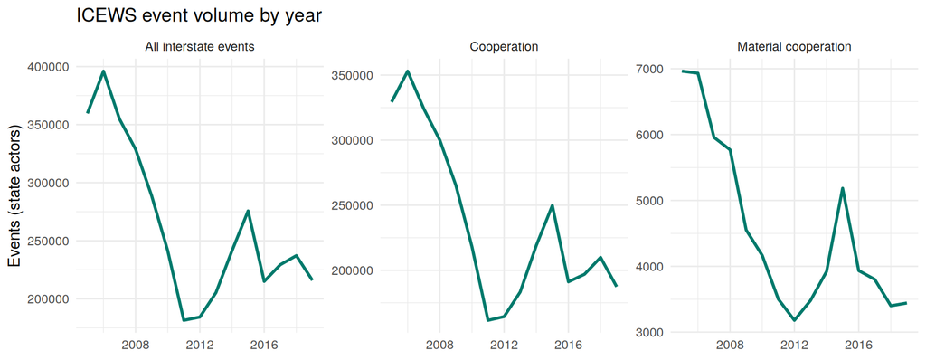

```r
ice %>% group_by(year) %>%
  summarize(`All interstate events` = sum(n_all), Cooperation = sum(coop),
            `Material cooperation` = sum(n_mcoop)) %>%
  pivot_longer(-year) %>%
  ggplot(aes(year, value)) + geom_line(linewidth = 1, color = "#00796B") +
  facet_wrap(~ name, scales = "free_y") +
  labs(x = NULL, y = "Events (state actors)", title = "ICEWS event volume by year") +
  theme_minimal()
```

## 3. Two-mode layer: donor → recipient

Is the ICEWS donor → recipient cooperation layer related to the CRS aid ties that define the replication network? This is a validity check on ICEWS as a tie measure.

```r
two <- grid %>%
  select(d_iso, r_iso, year, tie_dem, commit_dem, DO) %>%
  left_join(ice %>% select(d_iso = src_iso, r_iso = tgt_iso, year, coop, n_mcoop),
            by = c("d_iso", "r_iso", "year")) %>%
  mutate(across(c(coop, n_mcoop), ~ replace_na(.x, 0L)),
         commit_dem = pmax(commit_dem, 0))   # a few net-negative commitments (de-obligations) set to 0
# EU institutions (EUI) are not a country in ICEWS, so their ICEWS ties are always 0

two %>% filter(d_iso != "EUI") %>%
  group_by(`CRS democracy tie` = ifelse(tie_dem == 1, "yes", "no")) %>%
  summarize(dyad_years = n(), `share with any ICEWS cooperation` = mean(coop > 0),
            `mean ICEWS cooperation events` = mean(coop)) %>% knitr::kable(digits = 2)
```

| CRS democracy tie | dyad_years | share with any ICEWS cooperation | mean ICEWS cooperation events |
| --- | --- | --- | --- |
| no | 12117 | 0.41 | 10.15 |
| yes | 16863 | 0.64 | 32.68 |

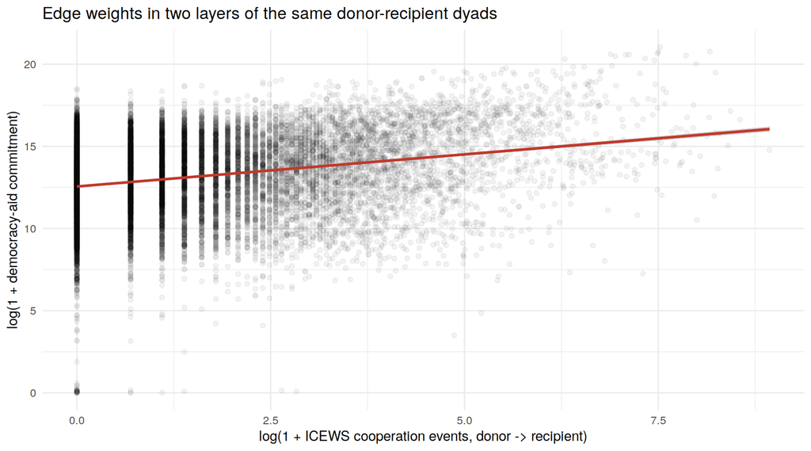

```r
two %>% filter(d_iso != "EUI", tie_dem == 1) %>%
  ggplot(aes(log1p(coop), log1p(commit_dem))) +
  geom_point(alpha = 0.05) + geom_smooth(method = "lm", color = "#C0392B") +
  labs(x = "log(1 + ICEWS cooperation events, donor -> recipient)",
       y = "log(1 + democracy-aid commitment)",
       title = "Edge weights in two layers of the same donor-recipient dyads") +
  theme_minimal()
```

```r
with(filter(two, d_iso != "EUI"), cor(log1p(coop), log1p(commit_dem)))   # correlation of the two edge weights
```

```
## [1] 0.2829005
```

## 4. One-mode layer: recipient – recipient cooperation

```r
# total interstate cooperation of each recipient (with any partner), both directions
tot <- bind_rows(ice %>% select(iso = src_iso, year, coop),
                 ice %>% select(iso = tgt_iso, year, coop)) %>%
  group_by(iso, year) %>% summarize(tot_coop = sum(coop), .groups = "drop")

# undirected dyadic cooperation (sum of both directions)
und <- ice %>%
  mutate(a = pmin(src_iso, tgt_iso), b = pmax(src_iso, tgt_iso)) %>%
  group_by(a, b, year) %>% summarize(coop = sum(coop), mcoop = sum(n_mcoop), .groups = "drop")

# recipient-recipient ties: k's share of j's cooperation, and j's share of k's
rr <- und %>% filter(a %in% recips, b %in% recips) %>%
  left_join(tot, by = c("a" = "iso", "year")) %>% rename(tot_a = tot_coop) %>%
  left_join(tot, by = c("b" = "iso", "year")) %>% rename(tot_b = tot_coop) %>%
  mutate(share_ab = coop / tot_a, share_ba = coop / tot_b,
         w   = pmax(share_ab, share_ba),          # edge weight: importance to either side
         tie = as.integer(w >= SHARE_TIE))

rr %>% group_by(year) %>%
  summarize(dyads_with_events = n(), ties = sum(tie),
            density = ties / choose(length(recips), 2)) %>% knitr::kable(digits = 3)
```

| year | dyads_with_events | ties | density |
| --- | --- | --- | --- |
| 2005 | 1826 | 333 | 0.056 |
| 2006 | 1875 | 310 | 0.052 |
| 2007 | 1842 | 295 | 0.049 |
| 2008 | 1915 | 279 | 0.047 |
| 2009 | 1756 | 292 | 0.049 |
| 2010 | 1815 | 309 | 0.052 |
| 2011 | 1667 | 318 | 0.053 |
| 2012 | 1733 | 319 | 0.053 |
| 2013 | 1734 | 303 | 0.051 |
| 2014 | 1729 | 303 | 0.051 |
| 2015 | 1828 | 283 | 0.047 |
| 2016 | 1609 | 296 | 0.049 |
| 2017 | 1543 | 293 | 0.049 |
| 2018 | 1617 | 277 | 0.046 |
| 2019 | 1520 | 287 | 0.048 |

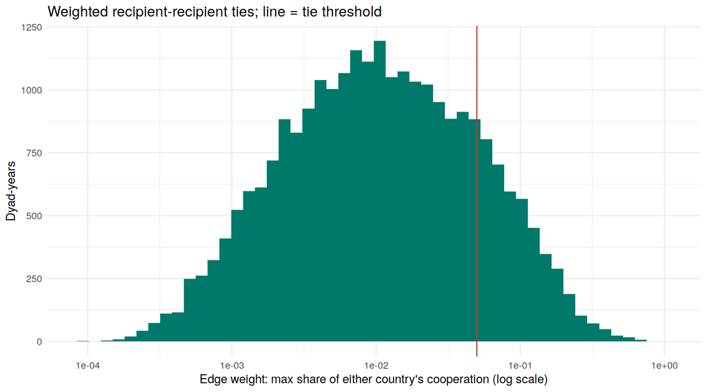

```r
ggplot(filter(rr, coop > 0), aes(w)) + geom_histogram(bins = 50, fill = "#00796B") +
  geom_vline(xintercept = SHARE_TIE, color = "#C0392B") + scale_x_log10() +
  labs(x = "Edge weight: max share of either country's cooperation (log scale)",
       y = "Dyad-years", title = "Weighted recipient-recipient ties; line = tie threshold") +
  theme_minimal()
```

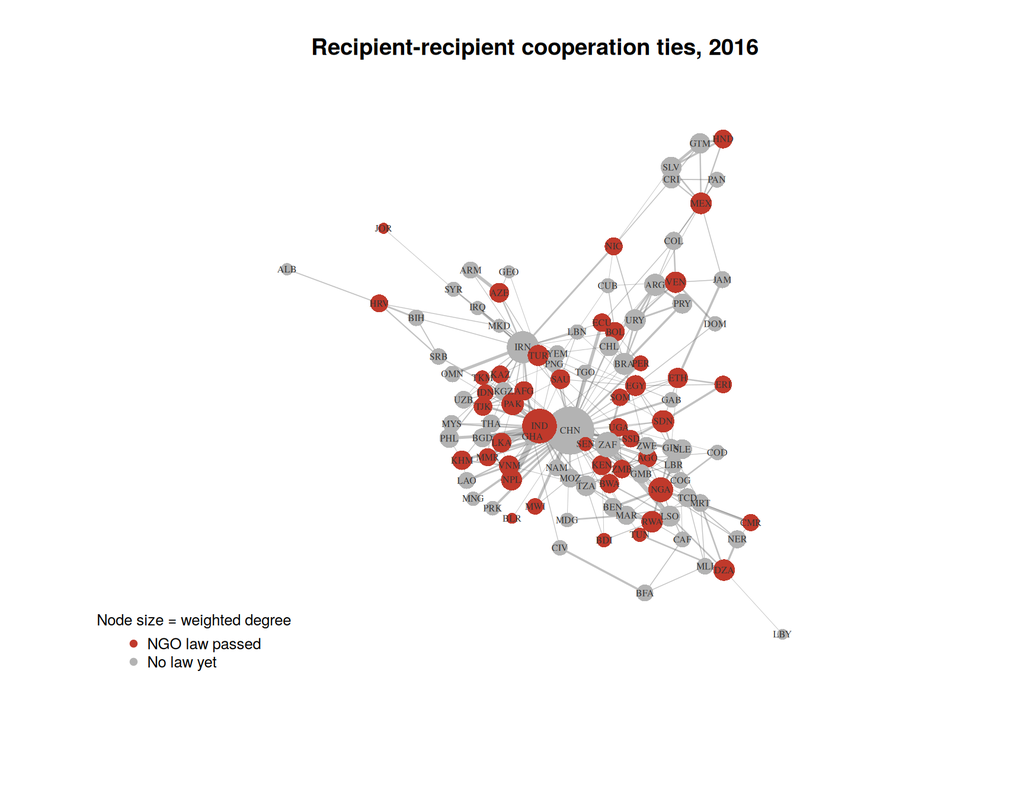

```r
y_plot <- 2016
e <- rr %>% filter(year == y_plot, tie == 1)
g <- graph_from_data_frame(e %>% select(a, b, w), directed = FALSE,
                           vertices = tibble(name = recips) %>% left_join(r_info, by = c("name" = "r_iso")))
g <- delete_vertices(g, degree(g) == 0)
V(g)$col <- ifelse(!is.na(V(g)$first_law) & V(g)$first_law < y_plot, "#C0392B", "grey70")
set.seed(508)
plot(g, layout = layout_with_fr(g), vertex.size = 3 + sqrt(strength(g, weights = E(g)$w)) * 6,
     vertex.color = V(g)$col, vertex.frame.color = NA, vertex.label.cex = 0.5,
     vertex.label.color = "grey20", edge.width = E(g)$w * 8, edge.color = adjustcolor("grey40", 0.4),
     main = paste0("Recipient-recipient cooperation ties, ", y_plot))
legend("bottomleft", bty = "n", cex = 0.8, pch = 19, col = c("#C0392B", "grey70"),
       legend = c("NGO law passed", "No law yet"), title = "Node size = weighted degree")
```

## 5. Patron layer

Each recipient’s **patron share** is the share of its interstate cooperation that is with the `PATRONS` set. If restrictive laws go with a pivot toward alternative patrons, the share should rise around passage.

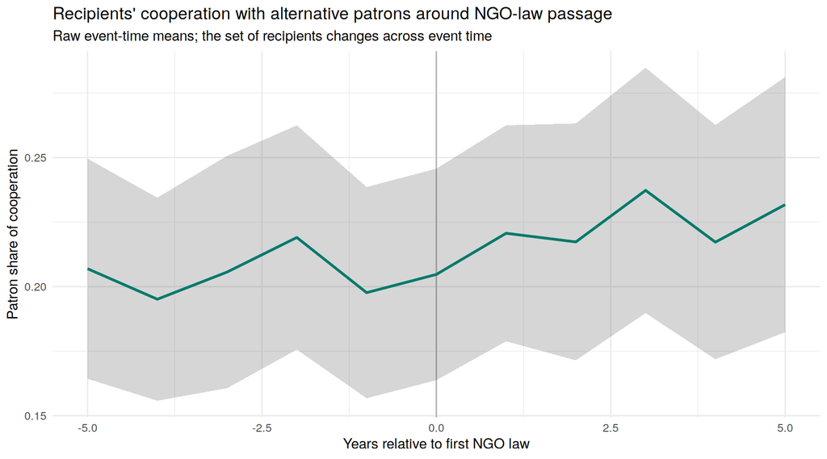

```r
pat <- und %>%
  mutate(r = case_when(a %in% recips & b %in% PATRONS ~ a,
                       b %in% recips & a %in% PATRONS ~ b)) %>%
  filter(!is.na(r)) %>% group_by(r_iso = r, year) %>%
  summarize(patron_coop = sum(coop), .groups = "drop") %>%
  right_join(tot %>% filter(iso %in% recips) %>% rename(r_iso = iso), by = c("r_iso", "year")) %>%
  mutate(patron_coop = replace_na(patron_coop, 0), patron_share = patron_coop / tot_coop) %>%
  left_join(r_info, by = "r_iso")

pat %>% filter(!is.na(first_law)) %>%
  mutate(t = year - first_law) %>% filter(between(t, -5, 5)) %>%
  group_by(t) %>% summarize(mean = mean(patron_share), se = sd(patron_share) / sqrt(n()), n = n()) %>%
  ggplot(aes(t, mean)) + geom_vline(xintercept = 0, color = "grey70") +
  geom_ribbon(aes(ymin = mean - 1.96 * se, ymax = mean + 1.96 * se), alpha = 0.2) +
  geom_line(color = "#00796B", linewidth = 1) +
  labs(x = "Years relative to first NGO law", y = "Patron share of cooperation",
       title = "Recipients' cooperation with alternative patrons around NGO-law passage",
       subtitle = "Raw event-time means; the set of recipients changes across event time") +
  theme_minimal()
```

## 6. Change: tie persistence

The same question for both layers: if a tie exists in *t−1*, how likely is it to exist in *t*, and how likely is a new tie to form?

```r
persist <- function(df, id_cols, tie_col) {
  df %>% arrange(year) %>% group_by(across(all_of(id_cols))) %>%
    mutate(lag_tie = lag(.data[[tie_col]]), lag_year = lag(year)) %>% ungroup() %>%
    filter(!is.na(lag_tie), year == lag_year + 1) %>%
    summarize(`P(tie | tie at t-1)`    = mean(.data[[tie_col]][lag_tie == 1]),
              `P(tie | no tie at t-1)` = mean(.data[[tie_col]][lag_tie == 0]))
}
# complete the recipient-recipient panel so absent dyads are observed zeros
rr_full <- expand_grid(a = recips, b = recips, year = YEARS) %>% filter(a < b) %>%
  left_join(rr %>% select(a, b, year, tie), by = c("a", "b", "year")) %>%
  mutate(tie = replace_na(tie, 0L))

bind_rows(
  `CRS democracy aid (donor -> recipient)` = persist(grid, c("d_iso", "r_iso"), "tie_dem"),
  `CRS economic aid (donor -> recipient)`  = persist(grid, c("d_iso", "r_iso"), "tie_econ"),
  `ICEWS cooperation (recipient - recipient)` = persist(rr_full, c("a", "b"), "tie"),
  .id = "Layer") %>% knitr::kable(digits = 3)
```

| Layer | P(tie \| tie at t-1) | P(tie \| no tie at t-1) |
| --- | --- | --- |
| CRS democracy aid (donor -> recipient) | 0.837 | 0.249 |
| CRS economic aid (donor -> recipient) | 0.933 | 0.313 |
| ICEWS cooperation (recipient - recipient) | 0.580 | 0.022 |

Aid ties are much stickier than ICEWS cooperation ties. Any temporal model of the aid layer needs a persistence (stability) term; otherwise other terms absorb that inertia.

## 7. Cross-layer triangles

Two layers share the recipients: the **aid layer** (donor *i* → recipient *j*, CRS democracy aid) and the **cooperation layer** (recipient *j* — recipient *k*, ICEWS).

- **Closed triangle:** *i* → *j*, *j* — *k*, and *i* → *k*.
- **Cross-layer closure:** the share of *j*’s cooperation partners that *i* also funds, compared with *i*’s overall funding density. A ratio above 1 means donors fund clusters of recipients that cooperate with each other.

```r
rr_ties <- rr %>% filter(tie == 1) %>% select(a, b, year)
rr_sym  <- bind_rows(rr_ties %>% rename(j = a, k = b), rr_ties %>% rename(j = b, k = a))
aid     <- grid %>% filter(tie_dem == 1) %>% select(i = d_iso, j = r_iso, year)

closure <- aid %>%                                   # i -> j
  inner_join(rr_sym, by = c("j", "year"), relationship = "many-to-many") %>%   # j - k
  left_join(aid %>% rename(k = j) %>% mutate(i_k = 1L), by = c("i", "k", "year")) %>%
  mutate(i_k = replace_na(i_k, 0L)) %>%
  group_by(i, year) %>% summarize(closed_share = mean(i_k), two_paths = n(), .groups = "drop") %>%
  left_join(grid %>% group_by(i = d_iso, year) %>% summarize(density = mean(tie_dem), .groups = "drop"),
            by = c("i", "year")) %>%
  mutate(ratio = closed_share / density)

closure %>% group_by(year) %>%
  summarize(`closed share` = weighted.mean(closed_share, two_paths),
            `donor density` = mean(density), ratio = weighted.mean(ratio, two_paths)) %>%
  knitr::kable(digits = 3)
```

| year | closed share | donor density | ratio |
| --- | --- | --- | --- |
| 2005 | 0.645 | 0.479 | 1.172 |
| 2006 | 0.609 | 0.454 | 1.134 |
| 2007 | 0.662 | 0.529 | 1.133 |
| 2008 | 0.692 | 0.565 | 1.136 |
| 2009 | 0.703 | 0.576 | 1.117 |
| 2010 | 0.694 | 0.605 | 1.067 |
| 2011 | 0.695 | 0.616 | 1.078 |
| 2012 | 0.667 | 0.605 | 1.028 |
| 2013 | 0.714 | 0.623 | 1.069 |
| 2014 | 0.682 | 0.586 | 1.070 |
| 2015 | 0.686 | 0.586 | 1.113 |
| 2016 | 0.673 | 0.588 | 1.052 |
| 2017 | 0.686 | 0.595 | 1.051 |
| 2018 | 0.701 | 0.660 | 1.002 |
| 2019 | 0.693 | 0.640 | 0.985 |

### Patron embedding and DO donors’ democracy ties after a law

A descriptive check of the hypothesis. Among democracy-oriented donors’ democracy-aid ties to recipients that have passed an NGO law, does the tie survive to *t* less often when, in *t−1*, the recipient was more embedded with patrons or had more cooperation partners that the donor also funds?

This is a dyad-independent logit, **not** an ERGM. It only checks whether the signal exists before the network model is built.

```r
shared_partners <- aid %>% inner_join(rr_sym, by = c("j", "year"), relationship = "many-to-many") %>%
  inner_join(aid %>% rename(k = j) %>% mutate(m = 1), by = c("i", "k", "year")) %>%
  count(i, j, year, name = "shared_k")

dat <- grid %>% arrange(year) %>% group_by(d_iso, r_iso) %>%
  mutate(lag_tie = lag(tie_dem), lag_year = lag(year)) %>% ungroup() %>%
  filter(lag_tie == 1, year == lag_year + 1, DO == 1, post_law == 1) %>%
  left_join(pat %>% transmute(r_iso, year = year + 1, patron_share_l = patron_share),
            by = c("r_iso", "year")) %>%
  left_join(shared_partners %>% transmute(d_iso = i, r_iso = j, year = year + 1, shared_k_l = shared_k),
            by = c("d_iso", "r_iso", "year")) %>%
  mutate(shared_k_l = replace_na(shared_k_l, 0))

fit <- glm(tie_dem ~ patron_share_l + log1p(shared_k_l) + factor(year), data = dat, family = binomial)
summary(fit)$coefficients[2:3, , drop = FALSE] %>% knitr::kable(digits = 3)
```

|  | Estimate | Std. Error | z value | Pr(>\|z\|) |
| --- | --- | --- | --- | --- |
| patron_share_l | -0.822 | 0.590 | -1.392 | 0.164 |
| log1p(shared_k_l) | 0.907 | 0.181 | 5.021 | 0.000 |

```r
nrow(dat)
```

```
## [1] 1143
```

## 8. Takeaways for the extension

- **Two-mode validity.** The section 3 table shows whether ICEWS donor → recipient cooperation tracks CRS democracy-aid ties; if it does, ICEWS can stand in for alignment layers where no aid data exist.
- **Weights.** Use shares, not counts, for every event-based layer, because ICEWS volume changes over time.
- **Stability.** Aid ties are highly persistent. The (S)TERGM needs a stability or persistence term, and formation and dissolution should be modelled separately.
- **Cross-layer closure.** A ratio above 1 in section 7 means donors fund clusters of mutually cooperating recipients. That supports including the cooperation layer as a dyadic covariate (lagged shared partners) in the aid-layer model.
- **Patron hypothesis.** The logit in section 7 is a first look at whether DO donors are more likely to drop democracy ties to post-law recipients that are embedded with alternative patrons. AidData’s lending data should replace the ICEWS patron share in the main analysis.